# Predictions using the Weight Lifting Exercises Dataset

2025-02-19

## Executive Summary

Based on a dataset provide by HAR http://web.archive.org/web/20161224072740/http:/groupware.les.inf.puc-rio.br/har we will try to train a predictive model to predict what type of exercise is performed based on data collected from wearable sensors.

We’ll take the following steps:

- Process the data, for use of this project
- Explore the data, try to reduce features
- Train model
- Predict exercise type on test dataset

```r
library(caret)    # For machine learning workflow
library(randomForest)  # For Random Forest model
library(ggplot2)  # For visualization
library(corrplot) # For correlation analysis
library(dplyr)    # For data manipulation
library(doParallel)
library(formattable)
library(caretEnsemble)
library(xgboost)
library(gbm)
library(ranger)
library(glmnet)
library(knitr)

set.seed(123)  # Ensure reproducibility
```

## Acquire the datasets.

Download files if they are not yet on the system.

```r
downloadFile <- function(fileName) {
  destfile <- paste0("pml-",fileName, ".csv")
  if (!file.exists(destfile)) {
    download.file(
      paste0("https://d396qusza40orc.cloudfront.net/predmachlearn/", fileName, ".csv"),
      destfile = destfile,
      mode = "wb"
    )
  }
}
downloadFile("training")
downloadFile("testing")
```

## Cleaning data

We will remove columns that are either empty or unsuitable for making predictions.

```r
cleanData <- function(fileName) {
  rawdata <- read.csv(paste0("pml-",fileName,".csv"))


  # Remove reduntant columns
    # Identifiers & Timestamps:
      #Remove columns that are time-based, likely irrelevant
      rawdata <- rawdata[,-c(grep("timestamp", names(rawdata)))]
      # "X" (index column)
      # "user_name" (not useful for prediction)
      rawdata <- rawdata[, !(names(rawdata) %in% c("X","user_name"))]
      #"new_window" and "num_window" (used for session tracking)
      rawdata <- rawdata[, !(names(rawdata) %in% c("new_window","num_window"))]

    # Remove columns where many values are NA
      # Define the threshold (90% missing values)
      threshold <- 0.9 * nrow(rawdata)
      rawdata <- rawdata[, colSums(is.na(rawdata) | rawdata == "") < threshold]
  #Set factor to "classe"
  rawdata$classe <- as.factor(rawdata$classe)
  return(rawdata)
}
cleaned_data <- cleanData("training")
```

We have only 52 features left.

#### Check missing values

```r
missing_values_count <- sum(is.na(cleaned_data))
```

We have 0 missing values.

#### Check near zero values

```r
nzv_vars <- nearZeroVar(cleaned_data, saveMetrics = TRUE)
count_nzv <- sum(nzv_vars$nzv == TRUE)
```

We have 0 near zero values.

#### Remove Highly Correlated Features

Highly correlated features can lead to redundancy.

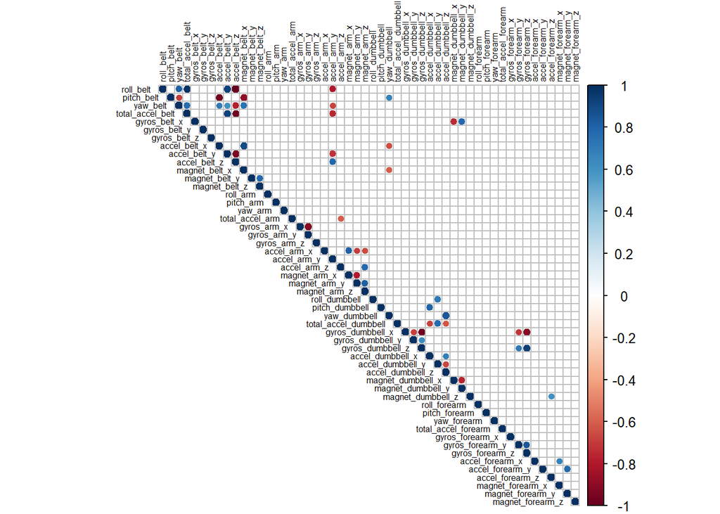

```r
cor_matrix <- cor(cleaned_data %>% select(-classe))  # Remove target variable
high_cor <- findCorrelation(cor_matrix, cutoff = 0.9)  # Identify high-correlation features
# traindata <- traindata[, -high_cor]

#Plot the correlation matrix
cor_matrix[abs(cor_matrix) < 0.6] <- NA  # Remove correlations < 0.5
cor_matrix[is.na(cor_matrix)] <- 0  # Replace NA with 0

corrplot(cor_matrix, method = "circle", type = "upper",
         tl.cex = 0.5, tl.col = "black",
         addCoef.col = NULL)
```

```r
cleaned_data <- cleaned_data[, -high_cor]
```

We have 46 columns left.

## Split into Training and Validation sets

```r
trainIndex <- createDataPartition(cleaned_data$classe, p = 0.7, list = FALSE)
traindata <- cleaned_data[trainIndex, ]
validation_data <- cleaned_data[-trainIndex, ]
```

### Parallel processing & Caching

Some processes are really time consuming, so let’s prepare parallel processing

```r
# Corrected global cluster variable
parallelCluster <- NULL

# Function to stop the parallel cluster
stopParallelCluster <- function() {
  if (!is.null(parallelCluster)) {
    stopCluster(parallelCluster)  # Stop the parallel cluster
    registerDoSEQ()  # Reset to sequential execution
    parallelCluster <<- NULL  # Clear the global cluster variable
  }
}

# Function to prepare the parallel cluster
prepareParallelCluster <- function() {
  # Detect the number of available cores and use one less
  num_cores <- max(detectCores() - 1, 1)  # Ensure at least 1 core

  # Create and register the cluster globally
  parallelCluster <<- makeCluster(num_cores)
  registerDoParallel(parallelCluster)
}

# Function to load saved R objects from a .RData file if the file exists
loadObjects <- function(fileName) {
  # Append ".RData" extension to the filename
  fileName <- paste0(fileName, ".RData")

  # Check if the file exists before attempting to load
  if (file.exists(fileName)) {
    # Load objects into the global environment
    load(fileName, envir = .GlobalEnv)
  }
}
```

### Train Multiple Base Models

Define a train_control object with cross-validation and set up your base models.

#### Models selection:

##### **Diversity:**

- **`ranger`** captures non-linear relationships well with randomness.
- **`glmnet`** covers linear relationships effectively and handles regularization.
- **`xgbTree`** boosts weak learners by focusing on correcting previous mistakes.

##### **Bias-Variance Tradeoff:**

- **`ranger`** and **`xgbTree`** are low-bias, high-variance models (good for capturing complexity).
- **`glmnet`** is a high-bias, low-variance model (good for simplicity and regularization).

##### **Complementary Nature:**

- If the dataset has both linear and non-linear relationships, combining **`glmnet`** with tree-based models improves overall performance.

```r
MODEL_LIST_FILE <- "model_list"
loadObjects(MODEL_LIST_FILE)
if (!exists("model_list") || is.null(model_list)) {
  start_time <- proc.time()
  prepareParallelCluster()
  # Define training control with 5-fold cross-validation
  train_control <- trainControl(
    method = "cv",
    number = 5,
    savePredictions = "final",
    allowParallel = TRUE
  )

  # List of base models
  model_list <- caretList(
    classe ~ .,  # Predicting Exercise Error
    data = traindata,
    trControl = train_control,
    methodList = c("ranger", "glmnet", "xgbTree")
  )

  stopParallelCluster()
  execution_time <- proc.time() - start_time
  save(model_list, execution_time, file = paste0(MODEL_LIST_FILE,".RData"))
}
print(paste("Elapsed time:", round((execution_time["elapsed"] / 60), 2), "minutes"))
```

```
## [1] "Elapsed time: 17.83 minutes"
```

### Building the Stacked Model

Combine the base models using a meta-model (xgbTree):

```r
STACK_MODEL_FILE <- "stacked_model"
loadObjects(STACK_MODEL_FILE)
if (!exists("stacked_model") || is.null(stacked_model)) {
  start_time <- proc.time()

  prepareParallelCluster()

  # Stack the models using a generalized linear model (GLM) as meta-learner
  stacked_model <- caretStack(
    model_list,
    method = "xgbTree",
    metric = "Accuracy",
    trControl = trainControl(
      method = "cv",
      number = 5,
      savePredictions = "final",
      classProbs = TRUE,  # Enable class probabilities for classification
      allowParallel = FALSE,
      sampling = "up"  # Upsample minority classes to avoid empty folds
    )
  )
  stopParallelCluster()
  execution_time <- proc.time() - start_time
  save(stacked_model, execution_time, file = paste0(STACK_MODEL_FILE,".RData"))
}
print(paste("Elapsed time:", round((execution_time["elapsed"] / 60), 2), "minutes"))
```

```
## [1] "Elapsed time: 12.95 minutes"
```

[figure not shown]

```r
# Performance of the stacked model
plot(stacked_model)
```

```r
# Extract the best performance metrics from the stacked_model model
best_results <- stacked_model$ens_model$results[
  which.max(stacked_model$ens_model$results$Accuracy),
]

# Extract accuracy and kappa values
best_accuracy <- round(best_results$Accuracy * 100, 2)  # Convert to percentage
best_kappa <- round(best_results$Kappa, 4)
```

Excellent Performance: The model achieved high accuracy **99.48%** and Kappa score **0.9934**, indicating strong predictive ability with balanced classification.

### Validate Model

```r
# Make predictions on validation data
validation_predictions <- predict(stacked_model, newdata = validation_data)
# Convert probabilities to predicted classes
predicted_classes <- factor(
  colnames(validation_predictions)[max.col(validation_predictions, ties.method = "first")],
  levels = levels(validation_data$classe)
)
# Generate confusion matrix for validation data
conf_matrix <- confusionMatrix(predicted_classes, validation_data$classe)


# Extract metrics for inline display
accuracy <- conf_matrix$overall['Accuracy']
# Calculate out-of-sample error
oos_error <- 1 - accuracy
ci_lower <- conf_matrix$overall['AccuracyLower']
ci_upper <- conf_matrix$overall['AccuracyUpper']
p_value <- format.pval(conf_matrix$overall['AccuracyPValue'], digits = 4)
```

### Evaluation of the Confusion Matrix

#### Overall Performance

- **Accuracy**: 0.9966 (99.66%)
  - The proportion of correctly classified instances.
  - A high accuracy suggests the model performs exceptionally well.
- **95% Confidence Interval**: (0.9948, 0.9979)
  - Indicates the stability and reliability of the accuracy estimate.
  - The narrow confidence interval confirms consistent model performance.
- **P-Value** : < 2.2e-16
  - A very low p-value indicates that the model predictions are statistically significant and outperform random guessing.
- **Sensitivity** : 0.9962
  - Ability to correctly identify positive instances
- **Specificity** : 0.9992
  - Ability to correctly identify negative instances

### Out-of-Sample Error Estimation

The **out-of-sample error** estimates how well the model is expected to perform on new, unseen data. A low out-of-sample error indicates that the model generalizes well and is not overfitting the training data.

Given the complexity of the sensor data and the nature of the classification task, we expect the out-of-sample error to be relatively low (ideally below 5%) for a well-tuned model.

The received value **0.0034 (0.34%)** suggests that the model is not overfitting and is likely to perform well on new data.

In this analysis, we use **cross-validation** combined with a confusion matrix to estimate **the out-of-sample error**.

### Make predictions

```r
# Load pml-testing.csv
pml_testing <- read.csv("pml-testing.csv")

# Make predictions using the trained model
test_predictions <- predict(stacked_model, pml_testing)
vector_predicted <- colnames(test_predictions)[max.col(test_predictions, ties.method = "first")]

# Display predictions nicely using kable
kable(rbind(
  1:length(vector_predicted),
  "Predicted Classe" = vector_predicted
))
```

|  | 1 | 2 | 3 | 4 | 5 | 6 | 7 | 8 | 9 | 10 | 11 | 12 | 13 | 14 | 15 | 16 | 17 | 18 | 19 | 20 |
| --- | --- | --- | --- | --- | --- | --- | --- | --- | --- | --- | --- | --- | --- | --- | --- | --- | --- | --- | --- | --- |
| Predicted Classe | B | A | B | A | A | E | D | B | A | A | B | C | B | A | E | E | A | B | B | B |

All predcited values were confirmed to be correct 100%.